# Assignment 1: Vector and Time Series Analysis

Author

Mizbah Ahmed Sresto

## Introduction

This analysis compares daily precipitation and soil moisture at 5 cm at two USCRN stations during 2025: Lafayette 13 SE, Louisiana, and Tucson 11 W, Arizona. The stations represent contrasting settings: the humid southeastern United States and the dry southwestern United States.

Precipitation is expressed in millimeters. Soil moisture is daily average volumetric water content, expressed in cubic meters of water per cubic meter of soil (m³/m³).

The analysis compares annual time series, distributions, and relationships between the two variables. It then examines differences between the six-month summer and winter groups specified in the assignment.

Data and column definitions: [NOAA USCRN daily data](https://www.ncei.noaa.gov/pub/data/uscrn/products/daily01/) and [NOAA documentation](https://www.ncei.noaa.gov/pub/data/uscrn/products/daily01/readme.txt).

## 1. Load packages

I installed the packages below prepare the data and create the figures.ggplot2 creates the graphs, dplyr organizes and summarizes the data, and tidyr adds missing dates so the daily time series is complete.

```r
# Load packages; do not reinstall them during rendering.
library(ggplot2)
library(dplyr)
library(tidyr)
# Apply the same basic appearance to all figures.
theme_set(theme_bw(base_size = 12))

# Keep station colors consistent throughout the report.
station_colors <- c(
  "Lafayette, LA" = "#0072B2",
  "Tucson, AZ" = "#D55E00"
)
```

## 2. Download the station records

Each file contains daily records for one station during 2025. The code downloads a file only if a local copy is not already present. The data folder is located alongside this Quarto document.

```r
# Create a folder for the raw station files.
dir.create("USCRN_data", showWarnings = FALSE)

# Allow sufficient time for a NOAA download.
options(timeout = 300)

base_url <- paste0(
  "https://www.ncei.noaa.gov/pub/data/",
  "uscrn/products/daily01/2025/"
)

file_la <- "CRND0103-2025-LA_Lafayette_13_SE.txt"
file_az <- "CRND0103-2025-AZ_Tucson_11_W.txt"

path_la <- file.path("USCRN_data", file_la)
path_az <- file.path("USCRN_data", file_az)

# Download missing files or replace empty files.
if (!file.exists(path_la) || file.size(path_la) == 0) {
  download.file(
    paste0(base_url, file_la),
    destfile = path_la,
    mode = "wb"
  )
}

if (!file.exists(path_az) || file.size(path_az) == 0) {
  download.file(
    paste0(base_url, file_az),
    destfile = path_az,
    mode = "wb"
  )
}
```

## 3. Read and select variables

NOAA files have no header row. Column 2 contains the local-standard-time date, column 10 contains daily precipitation, and column 19 contains daily average soil moisture at 5 cm.

```r
# Read the space-separated files.
la_raw <- read.table(
  path_la,
  header = FALSE,
  stringsAsFactors = FALSE
)

az_raw <- read.table(
  path_az,
  header = FALSE,
  stringsAsFactors = FALSE
)

# Check the expected NOAA file structure.
stopifnot(
  ncol(la_raw) == 28,
  ncol(az_raw) == 28
)

# Retain the variables needed for the assignment.
la_data <- la_raw %>%
  transmute(
    Date = as.Date(as.character(V2), format = "%Y%m%d"),
    Station = "Lafayette, LA",
    Precipitation = V10,
    Soil_moisture = V19
  )

az_data <- az_raw %>%
  transmute(
    Date = as.Date(as.character(V2), format = "%Y%m%d"),
    Station = "Tucson, AZ",
    Precipitation = V10,
    Soil_moisture = V19
  )

# Combine both stations into one table.
climate_data <- bind_rows(la_data, az_data)
```

## 4. Clean the records and check availability

Negative missing-data codes are replaced with `NA` for precipitation and soil moisture. Zero precipitation is retained as a valid observation.

I inserted the mssing dates without estimating their measurements. Each variable uses its available observations; scatter plots use only days with both measurements.

```r
# Check that dates are valid and station-date pairs are unique.
stopifnot(
  !anyNA(climate_data$Date),
  anyDuplicated(climate_data[c("Station", "Date")]) == 0
)

# Replace negative missing-data codes.
climate_data <- climate_data %>%
  mutate(
    Precipitation = ifelse(
      Precipitation < 0, NA_real_, Precipitation
    ),
    Soil_moisture = ifelse(
      Soil_moisture < 0, NA_real_, Soil_moisture
    )
  )

all_dates <- seq(
  as.Date("2025-01-01"),
  as.Date("2025-12-31"),
  by = "day"
)

# Retain 2025 and insert any absent dates as NA.
climate_data <- climate_data %>%
  filter(Date %in% all_dates) %>%
  group_by(Station) %>%
  complete(Date = all_dates) %>%
  ungroup() %>%
  arrange(Station, Date)

availability <- climate_data %>%
  group_by(Station) %>%
  summarise(
    Total_days = n(),
    Valid_precipitation = sum(!is.na(Precipitation)),
    Missing_precipitation = sum(is.na(Precipitation)),
    Valid_soil_moisture = sum(!is.na(Soil_moisture)),
    Missing_soil_moisture = sum(is.na(Soil_moisture)),
    .groups = "drop"
  )

# Confirm that both stations have sufficient values for plotting.
stopifnot(
  nrow(availability) == 2,
  all(availability$Total_days == 365),
  all(availability$Valid_precipitation > 1),
  all(availability$Valid_soil_moisture > 1),
  all(
    climate_data$Soil_moisture >= 0 &
      climate_data$Soil_moisture <= 1,
    na.rm = TRUE
  )
)

knitr::kable(
  availability,
  caption = "Availability of daily observations during 2025"
)
```

Availability of daily observations during 2025

| Station | Total_days | Valid_precipitation | Missing_precipitation | Valid_soil_moisture | Missing_soil_moisture |
| --- | --- | --- | --- | --- | --- |
| Lafayette, LA | 365 | 365 | 0 | 365 | 0 |
| Tucson, AZ | 365 | 365 | 0 | 364 | 1 |

## Part 1: Annual comparison

### 5. Precipitation time series

Vertical segments show daily precipitation amounts. Both station panels use the same axes to support comparison.

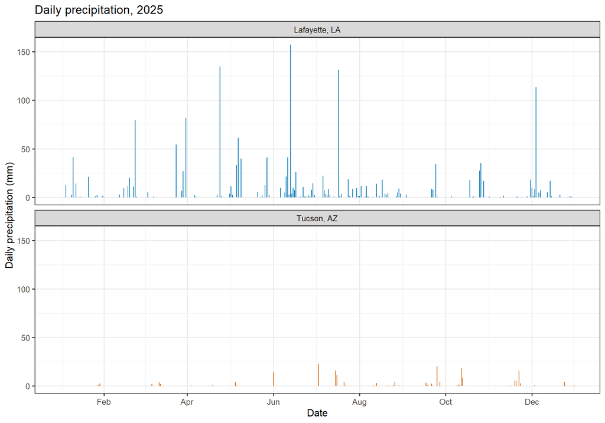

```r
p_rain_time <- ggplot(
  climate_data,
  aes(Date, Precipitation, color = Station)
) +
  geom_segment(
    aes(xend = Date, yend = 0),
    linewidth = 0.5,
    na.rm = TRUE
  ) +
  facet_wrap(~Station, ncol = 1) +
  scale_color_manual(values = station_colors) +
  scale_x_date(date_breaks = "2 months", date_labels = "%b") +
  labs(
    title = "Daily precipitation, 2025",
    x = "Date",
    y = "Daily precipitation (mm)"
  ) +
  theme(legend.position = "none")

print(p_rain_time)
```

### 6. Soil-moisture time series

The lines show daily soil moisture at 5 cm. Missing observations remain as gaps rather than being interpolated.

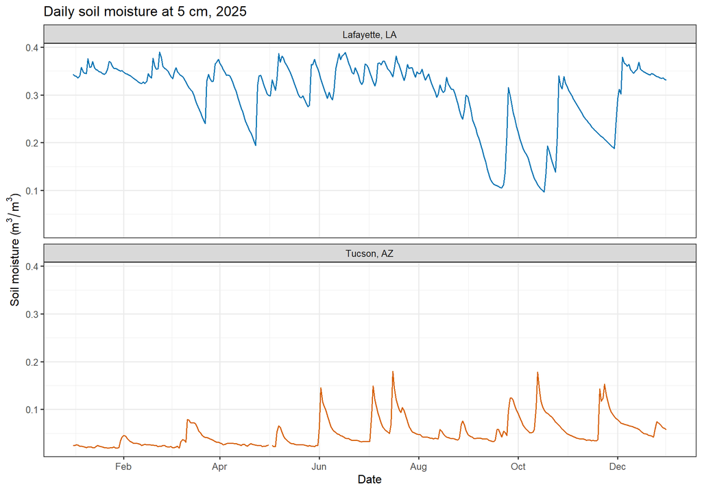

```r
p_sm_time <- ggplot(
  climate_data,
  aes(Date, Soil_moisture, color = Station)
) +
  geom_line(linewidth = 0.6, na.rm = TRUE) +
  facet_wrap(~Station, ncol = 1) +
  scale_color_manual(values = station_colors) +
  scale_x_date(date_breaks = "2 months", date_labels = "%b") +
  labs(
    title = "Daily soil moisture at 5 cm, 2025",
    x = "Date",
    y = expression("Soil moisture (" * m^3 / m^3 * ")")
  ) +
  theme(legend.position = "none")

print(p_sm_time)
```

### 7. Precipitation probability-density histograms

This analysis uses probability-density histograms to compare the distribution of daily precipitation at Lafayette and Tucson during 2025. Precipitation is grouped into 5-mm intervals, including days with no precipitation. Taller bars indicate more days within that range because all intervals have equal widths. The plots show which precipitation amounts were most common and how the distributions differed between stations.

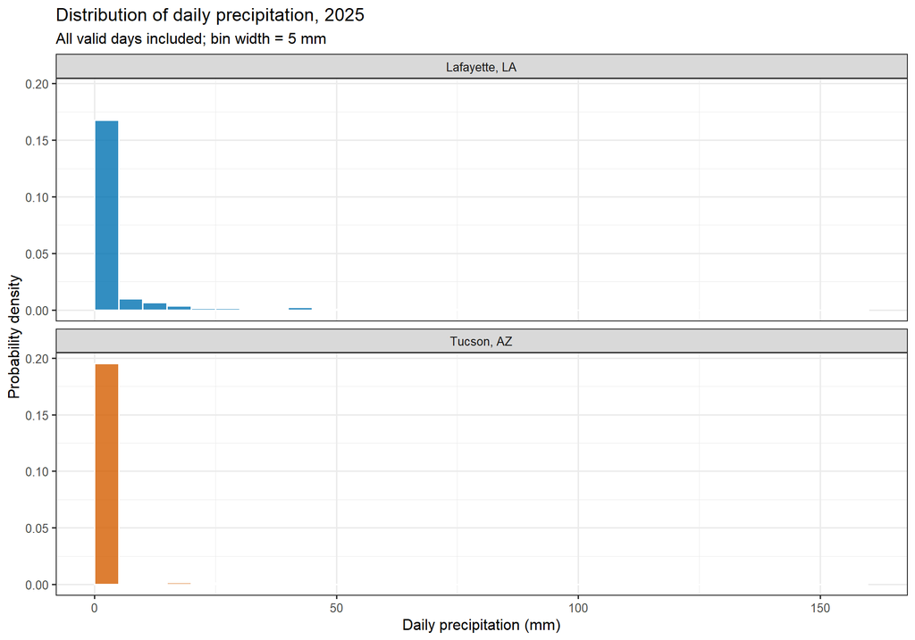

```r
# Define common bins starting at zero.
rain_max <- max(climate_data$Precipitation, na.rm = TRUE)

rain_breaks <- seq(
  0,
  (floor(rain_max / 5) + 1) * 5,
  by = 5
)

p_rain_hist <- ggplot(
  climate_data,
  aes(Precipitation, fill = Station)
) +
  geom_histogram(
    aes(y = after_stat(density)),
    breaks = rain_breaks,
    closed = "left",
    color = "white",
    alpha = 0.8,
    na.rm = TRUE
  ) +
  facet_wrap(~Station, ncol = 1) +
  scale_fill_manual(values = station_colors) +
  labs(
    title = "Distribution of daily precipitation, 2025",
    subtitle = "All valid days included; bin width = 5 mm",
    x = "Daily precipitation (mm)",
    y = "Probability density"
  ) +
  theme(legend.position = "none")

print(p_rain_hist)
```

### 8. Soil-moisture probability-density histograms

I did this analysis to compare the distribution of daily soil moisture at 5 cm between Lafayette and Tucson during 2025. I grouped soil-moisture values into intervals of 0.02 m³/m³ and added a smooth density curve to show the overall pattern. These plots help identify the most common soil-moisture ranges and compare their variability between stations. Missing observations were excluded, and the density curves were restricted to soil-moisture values between 0 and 1 m³/m³.

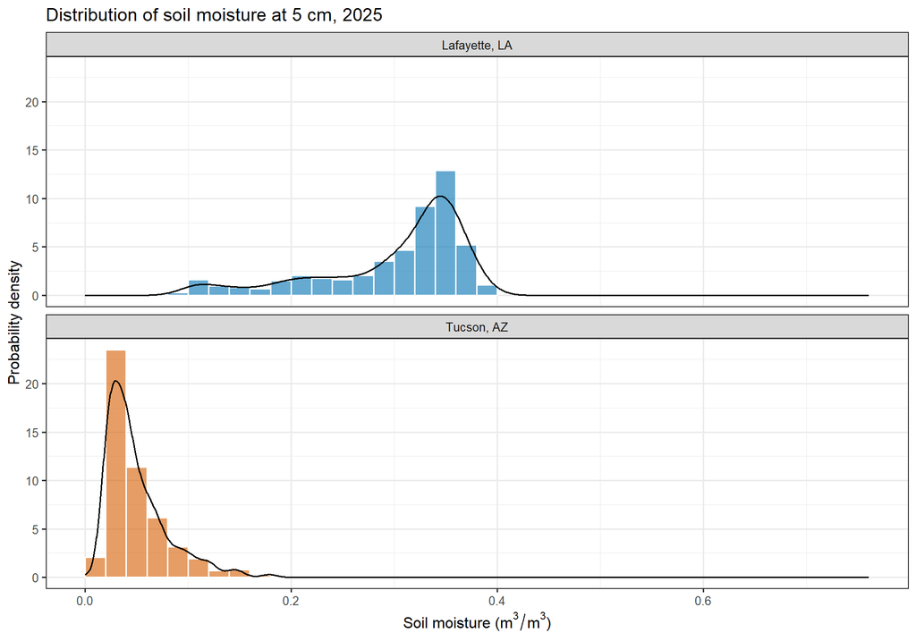

```r
p_sm_hist <- ggplot(
  climate_data,
  aes(Soil_moisture, fill = Station)
) +
  geom_histogram(
    aes(y = after_stat(density)),
    binwidth = 0.02,
    boundary = 0,
    color = "white",
    alpha = 0.6,
    na.rm = TRUE
  ) +
  geom_density(
    fill = NA,
    color = "black",
    linewidth = 0.7,
    bounds = c(0, 1),
    na.rm = TRUE
  ) +
  facet_wrap(~Station, ncol = 1) +
  scale_fill_manual(values = station_colors) +
  labs(
    title = "Distribution of soil moisture at 5 cm, 2025",
    x = expression("Soil moisture (" * m^3 / m^3 * ")"),
    y = "Probability density"
  ) +
  theme(legend.position = "none")

print(p_sm_hist)
```

### 9. Precipitation and soil-moisture scatter plots

To explore the relationship between precipitation and soil moisture, I created scatter plots for Lafayette and Tucson using their 2025 records. Each point represents daily precipitation and soil moisture at 5 cm from the same day. Days with missing measurements were excluded, and both panels use the same axis scales for comparison. The plots show whether higher precipitation coincides with higher soil moisture, although they do not capture delayed responses to rainfall.

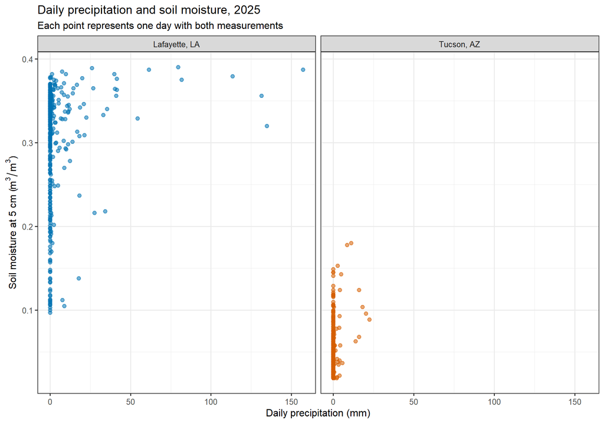

```r
paired_data <- climate_data %>%
  filter(
    !is.na(Precipitation),
    !is.na(Soil_moisture)
  )

p_scatter <- ggplot(
  paired_data,
  aes(Precipitation, Soil_moisture, color = Station)
) +
  geom_point(alpha = 0.55, size = 2) +
  facet_wrap(~Station, nrow = 1) +
  scale_color_manual(values = station_colors) +
  labs(
    title = "Daily precipitation and soil moisture, 2025",
    subtitle = "Each point represents one day with both measurements",
    x = "Daily precipitation (mm)",
    y = expression("Soil moisture at 5 cm (" * m^3 / m^3 * ")")
  ) +
  theme(legend.position = "none")

print(p_scatter)
```

### 10. Annual summary statistics

To support the graphical comparisons, I calculated annual summary statistics for each station. For precipitation, these include the total recorded amount, daily mean, daily maximum, and number of wet days, defined as days with at least 1 mm of precipitation. For soil moisture, I calculated the mean, median, and standard deviation to describe typical conditions and variability. Missing observations were excluded, and valid-day counts were reported to show data availability. Precipitation sums represent complete annual totals only when all 365 daily measurements are available.

```r
annual_rain <- climate_data %>%
  group_by(Station) %>%
  summarise(
    Valid_days = sum(!is.na(Precipitation)),
    Observed_sum_mm = sum(Precipitation, na.rm = TRUE),
    Mean_daily_mm = mean(Precipitation, na.rm = TRUE),
    Maximum_daily_mm = max(Precipitation, na.rm = TRUE),
    Wet_days = sum(Precipitation >= 1, na.rm = TRUE),
    .groups = "drop"
  )

annual_sm <- climate_data %>%
  group_by(Station) %>%
  summarise(
    Valid_days = sum(!is.na(Soil_moisture)),
    Mean = mean(Soil_moisture, na.rm = TRUE),
    Median = median(Soil_moisture, na.rm = TRUE),
    SD = sd(Soil_moisture, na.rm = TRUE),
    .groups = "drop"
  )

knitr::kable(
  annual_rain,
  digits = 2,
  caption = "Annual precipitation statistics"
)
```

Annual precipitation statistics

| Station | Valid_days | Observed_sum_mm | Mean_daily_mm | Maximum_daily_mm | Wet_days |
| --- | --- | --- | --- | --- | --- |
| Lafayette, LA | 365 | 1781.3 | 4.88 | 157.2 | 97 |
| Tucson, AZ | 365 | 185.7 | 0.51 | 22.4 | 25 |

```r
knitr::kable(
  annual_sm,
  digits = 3,
  caption = "Annual soil-moisture statistics (m³/m³)"
)
```

Annual soil-moisture statistics (m³/m³)

| Station | Valid_days | Mean | Median | SD |
| --- | --- | --- | --- | --- |
| Lafayette, LA | 365 | 0.301 | 0.33 | 0.071 |
| Tucson, AZ | 364 | 0.050 | 0.04 | 0.030 |

## Part 2: Seasonal comparison

### 11. Define the seasons

Following the assignment, I grouped March–August as summer and January–February plus September–December as winter, using only 2025 records. I also counted valid precipitation and soil-moisture observations for each station and season.

```r
seasonal_data <- climate_data %>%
  mutate(
    # Extract the calendar month.
    Month = as.integer(format(Date, "%m")),

    # Apply the assignment's six-month definitions.
    Season = ifelse(
      Month %in% 3:8,
      "Summer (MAMJJA)",
      "Winter (SONDJF)"
    ),

    # Control the order of seasons in plots and tables.
    Season = factor(
      Season,
      levels = c("Summer (MAMJJA)", "Winter (SONDJF)")
    )
  )

seasonal_counts <- seasonal_data %>%
  group_by(Station, Season) %>%
  summarise(
    Total_days = n(),
    Valid_precipitation = sum(!is.na(Precipitation)),
    Valid_soil_moisture = sum(!is.na(Soil_moisture)),
    .groups = "drop"
  )

# Check that each group has enough observations.
stopifnot(
  nrow(seasonal_counts) == 4,
  all(seasonal_counts$Valid_precipitation > 1),
  all(seasonal_counts$Valid_soil_moisture > 1)
)

knitr::kable(
  seasonal_counts,
  caption = "Seasonal sample sizes"
)
```

Seasonal sample sizes

| Station | Season | Total_days | Valid_precipitation | Valid_soil_moisture |
| --- | --- | --- | --- | --- |
| Lafayette, LA | Summer (MAMJJA) | 184 | 184 | 184 |
| Lafayette, LA | Winter (SONDJF) | 181 | 181 | 181 |
| Tucson, AZ | Summer (MAMJJA) | 184 | 184 | 183 |
| Tucson, AZ | Winter (SONDJF) | 181 | 181 | 181 |

### 12. Multivariate plot type 1: Precipitation boxplots

These grouped boxplots compare daily precipitation between stations and seasons. Faint points show individual daily measurements, including extreme events. All valid days are included, so frequent zero-precipitation days may compress the boxes near zero.

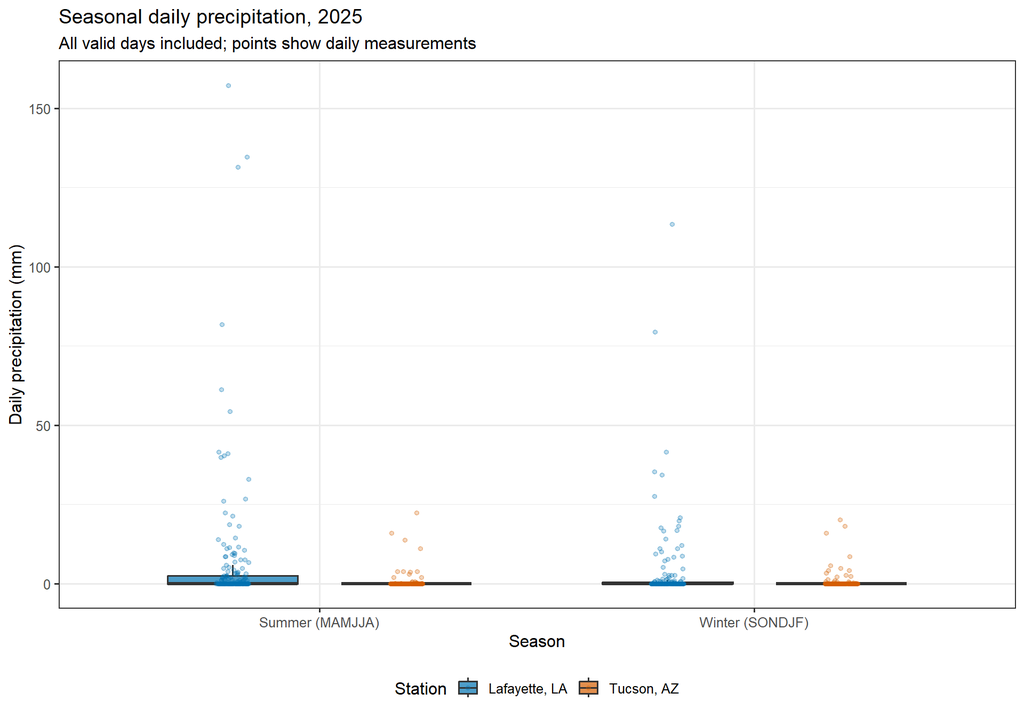

```r
p_season_rain <- ggplot(
  seasonal_data,
  aes(Season, Precipitation, fill = Station)
) +
  geom_boxplot(
    position = position_dodge(width = 0.8),
    width = 0.6,
    alpha = 0.7,
    outlier.shape = NA,
    na.rm = TRUE
  ) +
  geom_point(
    aes(color = Station),
    position = position_jitterdodge(
      jitter.width = 0.15,
      dodge.width = 0.8,
      seed = 123
    ),
    alpha = 0.25,
    size = 1.2,
    na.rm = TRUE
  ) +
  scale_fill_manual(values = station_colors) +
  scale_color_manual(values = station_colors) +
  labs(
    title = "Seasonal daily precipitation, 2025",
    subtitle = "All valid days included; points show daily measurements",
    x = "Season",
    y = "Daily precipitation (mm)"
  ) +
  theme(legend.position = "bottom")

print(p_season_rain)
```

### 13. Multivariate plot type 1: Soil-moisture boxplots

These boxplots compare soil moisture at 5 cm between stations and seasons. The line inside each box shows the median, while the box contains the middle 50% of observations, helping compare typical moisture levels and variability.

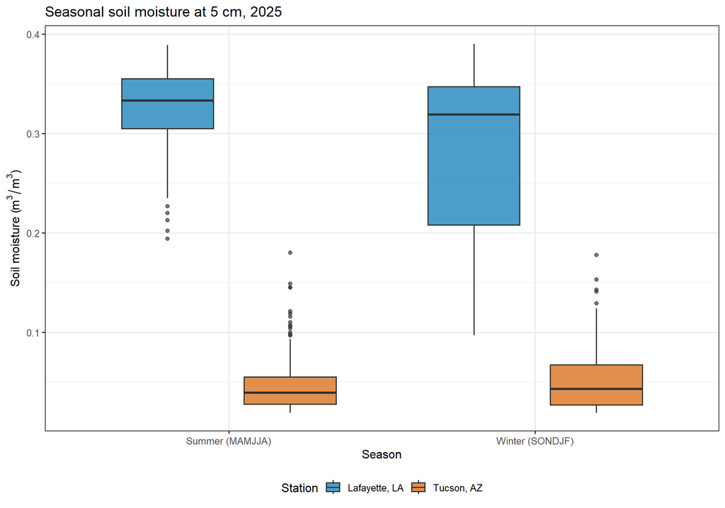

```r
p_season_sm <- ggplot(
  seasonal_data,
  aes(Season, Soil_moisture, fill = Station)
) +
  geom_boxplot(
    position = position_dodge(width = 0.8),
    width = 0.6,
    alpha = 0.7,
    na.rm = TRUE
  ) +
  scale_fill_manual(values = station_colors) +
  labs(
    title = "Seasonal soil moisture at 5 cm, 2025",
    x = "Season",
    y = expression("Soil moisture (" * m^3 / m^3 * ")")
  ) +
  theme(legend.position = "bottom")

print(p_season_sm)
```

### 14. Multivariate plot type 2: Seasonal scatter plots

These plots show precipitation and soil moisture together, with season represented by point color and shape and station represented by panels.

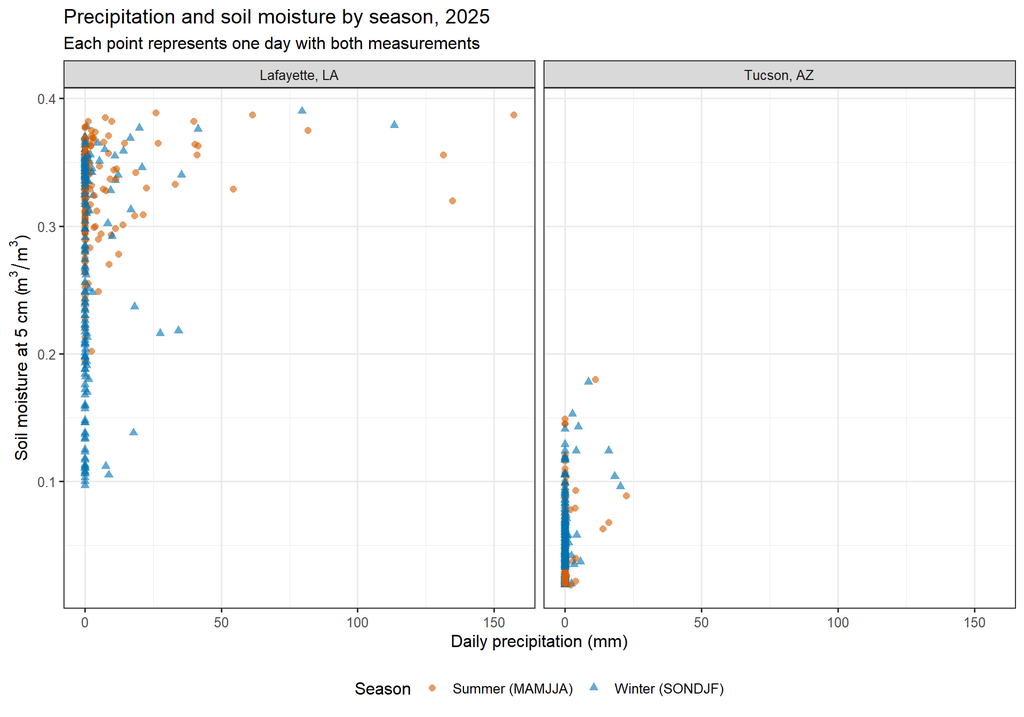

```r
seasonal_pairs <- seasonal_data %>%
  filter(
    !is.na(Precipitation),
    !is.na(Soil_moisture)
  )

season_colors <- c(
  "Summer (MAMJJA)" = "#D55E00",
  "Winter (SONDJF)" = "#0072B2"
)

p_season_scatter <- ggplot(
  seasonal_pairs,
  aes(
    Precipitation,
    Soil_moisture,
    color = Season,
    shape = Season
  )
) +
  geom_point(alpha = 0.6, size = 2) +
  facet_wrap(~Station, nrow = 1) +
  scale_color_manual(values = season_colors) +
  scale_shape_manual(values = c(16, 17)) +
  labs(
    title = "Precipitation and soil moisture by season, 2025",
    subtitle = "Each point represents one day with both measurements",
    x = "Daily precipitation (mm)",
    y = expression("Soil moisture at 5 cm (" * m^3 / m^3 * ")")
  ) +
  theme(legend.position = "bottom")

print(p_season_scatter)
```

### 15. Seasonal summary statistics

These tables summarize precipitation totals, daily means, and wet-day percentages for each station and season, along with soil-moisture means, medians, and standard deviations. Wet days have at least 1 mm of precipitation. Missing measurements are excluded, and valid-day counts show data availability.

```r
seasonal_rain <- seasonal_data %>%
  group_by(Station, Season) %>%
  summarise(
    Valid_days = sum(!is.na(Precipitation)),
    Observed_sum_mm = sum(Precipitation, na.rm = TRUE),
    Mean_daily_mm = mean(Precipitation, na.rm = TRUE),
    Wet_day_percent = 100 * mean(
      Precipitation >= 1,
      na.rm = TRUE
    ),
    .groups = "drop"
  )

seasonal_sm <- seasonal_data %>%
  group_by(Station, Season) %>%
  summarise(
    Valid_days = sum(!is.na(Soil_moisture)),
    Mean = mean(Soil_moisture, na.rm = TRUE),
    Median = median(Soil_moisture, na.rm = TRUE),
    SD = sd(Soil_moisture, na.rm = TRUE),
    .groups = "drop"
  )

knitr::kable(
  seasonal_rain,
  digits = 2,
  caption = "Seasonal precipitation statistics"
)
```

Seasonal precipitation statistics

| Station | Season | Valid_days | Observed_sum_mm | Mean_daily_mm | Wet_day_percent |
| --- | --- | --- | --- | --- | --- |
| Lafayette, LA | Summer (MAMJJA) | 184 | 1202.2 | 6.53 | 34.24 |
| Lafayette, LA | Winter (SONDJF) | 181 | 579.1 | 3.20 | 18.78 |
| Tucson, AZ | Summer (MAMJJA) | 184 | 88.1 | 0.48 | 5.98 |
| Tucson, AZ | Winter (SONDJF) | 181 | 97.6 | 0.54 | 7.73 |

```r
knitr::kable(
  seasonal_sm,
  digits = 3,
  caption = "Seasonal soil-moisture statistics (m³/m³)"
)
```

Seasonal soil-moisture statistics (m³/m³)

| Station | Season | Valid_days | Mean | Median | SD |
| --- | --- | --- | --- | --- | --- |
| Lafayette, LA | Summer (MAMJJA) | 184 | 0.326 | 0.333 | 0.038 |
| Lafayette, LA | Winter (SONDJF) | 181 | 0.276 | 0.319 | 0.086 |
| Tucson, AZ | Summer (MAMJJA) | 183 | 0.047 | 0.039 | 0.028 |
| Tucson, AZ | Winter (SONDJF) | 181 | 0.052 | 0.043 | 0.031 |

## Conclusions

The 2025 records show that Lafayette received 1781.3 mm of precipitation, compared with 185.7 mm at Tucson. Both stations had complete daily precipitation records. Mean soil moisture at 5 cm was 0.301 m³/m³ at Lafayette and 0.05 m³/m³ at Tucson. These results provide a numerical comparison of precipitation and near-surface soil-water conditions at the two stations.

Seasonal mean daily precipitation at Lafayette was 6.53 mm in summer and 3.2 mm in winter. At Tucson, the corresponding values were 0.48 and 0.54 mm. Mean soil moisture in summer and winter was 0.326 and 0.276 m³/m³ at Lafayette, compared with 0.047 and 0.052 m³/m³ at Tucson.

Together, the time series, histograms, boxplots, and scatter plots describe the timing, distribution, and seasonal variability of these measurements. The scatter plots assess same-day associations and do not establish causation or capture delayed soil-moisture responses. The findings apply to these two stations during 2025 and should not be interpreted as long-term climate patterns.

## Appendix: Saving the figures

The following code saves all eight figures as PNG files in the USCRN_figures folder at 300 dpi. The figures are also embedded in the HTML report.

```r
# Create the output folder if it does not already exist.
dir.create("USCRN_figures", showWarnings = FALSE)

# Store the eight plot objects with descriptive filenames.
all_plots <- list(
  "01_precipitation_timeseries" = p_rain_time,
  "02_soil_moisture_timeseries" = p_sm_time,
  "03_precipitation_histograms" = p_rain_hist,
  "04_soil_moisture_histograms" = p_sm_hist,
  "05_annual_scatterplots" = p_scatter,
  "06_seasonal_precipitation" = p_season_rain,
  "07_seasonal_soil_moisture" = p_season_sm,
  "08_seasonal_scatterplots" = p_season_scatter
)

# Save each figure at 10 × 7 inches and 300 dpi.
for (plot_name in names(all_plots)) {
  ggsave(
    filename = file.path(
      "USCRN_figures",
      paste0(plot_name, ".png")
    ),
    plot = all_plots[[plot_name]],
    width = 10,
    height = 7,
    units = "in",
    dpi = 300
  )
}
```

## Part 3: Soil moisture at different depths and precipitation (Extra Credits)

To examine how soil moisture varies with depth, I plotted the daily records at 5, 10, 20, 50, and 100 cm for Lafayette during 2025. Precipitation is shown as downward bars on an inverted right axis, following the plotting layout illustrated in [Cheng et al. (2021), Figure 4](https://doi.org/10.3389/fpls.2021.609529). Displaying these measurements together helps compare precipitation events with wetting and drying patterns throughout the soil profile.

### Prepare the data

The code below selects precipitation and all five soil-moisture layers. Missing measurements are retained as gaps rather than replaced with zero.

```r
# Select measurements from the original Lafayette station file.
soil_profile <- la_raw %>%
  transmute(
    Date = as.Date(as.character(V2), format = "%Y%m%d"),
    Precipitation = V10,
    `5 cm` = V19,
    `10 cm` = V20,
    `20 cm` = V21,
    `50 cm` = V22,
    `100 cm` = V23
  ) %>%
  mutate(
    # Negative codes indicate missing values for these variables.
    across(
      -Date,
      ~ifelse(.x < 0, NA_real_, .x)
    )
  ) %>%
  filter(
    Date >= as.Date("2025-01-01"),
    Date <= as.Date("2025-12-31")
  ) %>%
  complete(
    Date = seq(
      as.Date("2025-01-01"),
      as.Date("2025-12-31"),
      by = "day"
    )
  ) %>%
  arrange(Date)

# Keep the depth columns in their physical order.
depth_names <- c("5 cm", "10 cm", "20 cm", "50 cm", "100 cm")

# Check how many valid observations are available at each depth.
depth_availability <- data.frame(
  Depth = depth_names,
  Valid_days = sapply(
    soil_profile[depth_names],
    function(x) sum(!is.na(x))
  ),
  row.names = NULL
)

knitr::kable(
  depth_availability,
  caption = "Available soil-moisture observations at Lafayette, 2025"
)
```

Available soil-moisture observations at Lafayette, 2025

| Depth | Valid_days |
| --- | --- |
| 5 cm | 365 |
| 10 cm | 365 |
| 20 cm | 365 |
| 50 cm | 365 |
| 100 cm | 365 |

```r
# Confirm that every selected layer and precipitation have data.
stopifnot(
  all(depth_availability$Valid_days > 0),
  any(!is.na(soil_profile$Precipitation))
)
```

### Plot the combined time series

Colored lines show soil moisture against the left axis. Black bars show precipitation against the right axis, which starts at zero at the top and increases downward. Both measurements share the same dates.

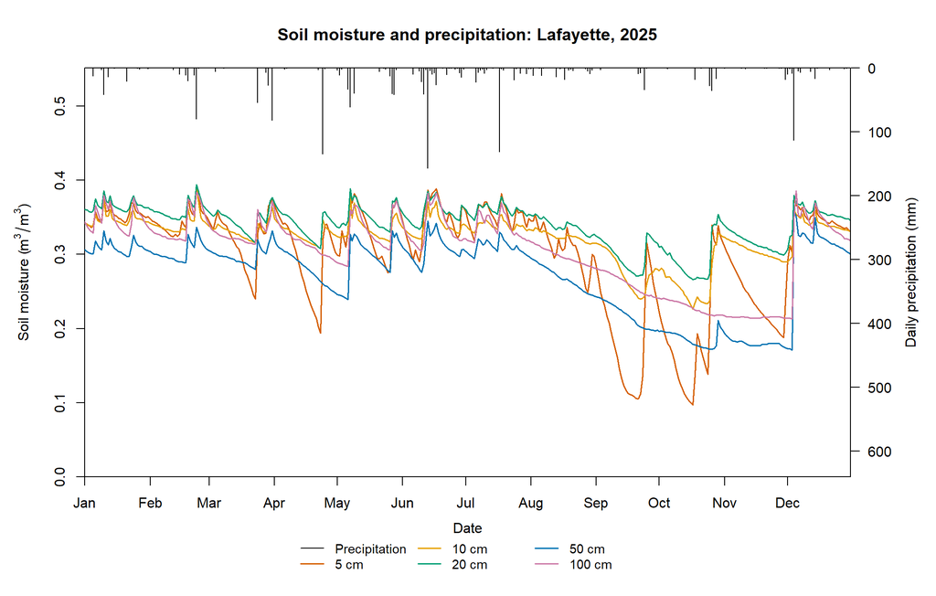

Daily soil moisture at five depths and precipitation at Lafayette 13 SE, Louisiana, in 2025. Precipitation uses the inverted right axis.

```r
# Define a function so the same figure can be displayed and saved.
plot_soil_profile <- function() {

  # Restore the original graphics settings when the function finishes.
  old_par <- par(no.readonly = TRUE)
  on.exit(par(old_par))

  # Leave room for both y-axis titles and the bottom legend.
  par(mar = c(7, 5, 4, 5))

  dates <- soil_profile$Date
  soil_values <- as.matrix(soil_profile[depth_names])

  depth_colors <- c(
    "#D55E00", "#E69F00", "#009E73", "#0072B2", "#CC79A7"
  )

  # Set plot limits from the observed measurements.
  sm_max <- max(soil_values, na.rm = TRUE)
  rain_max <- max(soil_profile$Precipitation, na.rm = TRUE)

  # Add space above the soil-moisture lines.
  sm_top <- max(0.05, sm_max * 1.4)

  # Keep precipitation bars mainly in the upper part of the figure.
  # This changes the display scale, not the precipitation values.
  rain_axis_max <- max(10, ceiling(rain_max / 10) * 10) * 4

  # First layer: initialize the soil-moisture axes.
  plot(
    dates,
    rep(NA_real_, length(dates)),
    type = "n",
    xlim = range(dates),
    ylim = c(0, sm_top),
    xaxs = "i",
    yaxs = "i",
    xaxt = "n",
    xlab = "",
    ylab = expression("Soil moisture (" * m^3 / m^3 * ")"),
    main = "Soil moisture and precipitation: Lafayette, 2025"
  )

  # Label the shared time axis by month.
  month_ticks <- seq(
    as.Date("2025-01-01"),
    as.Date("2025-12-01"),
    by = "month"
  )

  axis.Date(
    side = 1,
    at = month_ticks,
    format = "%b"
  )
  mtext("Date", side = 1, line = 2.5)

  # Add one line for each depth; NA values create gaps.
  for (i in seq_along(depth_names)) {
    lines(
      dates,
      soil_values[, i],
      col = depth_colors[i],
      lwd = 1.6
    )
  }

  # Second layer: overlay precipitation using an inverted y-axis.
  par(new = TRUE)

  plot(
    dates,
    soil_profile$Precipitation,
    type = "h",
    xlim = range(dates),
    ylim = c(rain_axis_max, 0),
    xaxs = "i",
    yaxs = "i",
    axes = FALSE,
    xlab = "",
    ylab = "",
    col = "black",
    lwd = 1
  )

  # The right axis shows actual precipitation amounts in mm.
  axis(side = 4, las = 1)
  mtext("Daily precipitation (mm)", side = 4, line = 3)

  # Identify the precipitation bars and each soil depth.
  legend(
    "bottom",
    inset = c(0, -0.25),
    legend = c("Precipitation", depth_names),
    col = c("black", depth_colors),
    lty = 1,
    lwd = c(1, rep(1.6, length(depth_names))),
    ncol = 3,
    bty = "n",
    xpd = NA,
    cex = 0.9
  )
}

# Display the figure in the HTML report.
plot_soil_profile()
```

### Save the figure

A separate PNG copy is saved below. The same figure is already included in the HTML report.

```r
dir.create("USCRN_figures", showWarnings = FALSE)

png(
  filename = file.path(
    "USCRN_figures",
    "09_soil_moisture_depths_precipitation.png"
  ),
  width = 11,
  height = 7,
  units = "in",
  res = 300
)

plot_soil_profile()

# Close the file so the PNG is saved completely.
dev.off()
```